# Übung A

RaumAn3

RaumAn

Heute berechnen wir Moran’s I auf verschiedenen Datensätzen und vergleichen die Resultate.

Patrick Laube , Nils Ratnaweera , Nikolaos Bakogiannis  
08-19-2021

Für die Berechnung von Morans $I$ benutzen wir kein externes Package, sondern erarbeiten uns alles selber, basierend auf der Formel von Moran’s $I$:

$$I = \frac{n}{\sum_{i=1}^n (y_i - \bar{y})^2} \times \frac{\sum_{i=1}^n \sum_{j=1}^n w_{ij}(y_i - \bar{y})(y_j - \bar{y})}{\sum_{i=1}^n \sum_{j=1}^n w_{ij}}$$

Diese sieht sehr beeindruckend aus, aber wenn wir die Formel in ihre Einzelbestandteile aufteilen, sehen wir, dass diese in sich gar nicht so komplex sind.

Als erster Schritt müssen wir die notwendigen Libraries und Geodaten laden:

- bezirke.gpkg
- wasserverfuegbarkeit_bode.gpkg

```r
library(tidyverse)
library(sf)

bezirke <- read_sf("bezirke.gpkg")

wasser <- read_sf("wasserverfuegbarkeit_boden.gpkg")

wasser <- wasser %>%
  st_set_crs(4326) %>%
  st_transform(2056)

bezirke <- st_set_crs(bezirke, 2056)
```

Nun können wir die mittlere Wasserverfügbarkeit pro Bezirk berechnen. Visualisiert dies in einem ersten Schritt und notiert Euch, was für einen Wert Ihr von Moran’s $I$ erwartet (eher -1 oder eher 1 oder nahe bei 0?). Der Plot muss nicht genau so aussehen wie der unsere.

```r
wasser_bezirke <- aggregate(wasser,bezirke, mean)
```

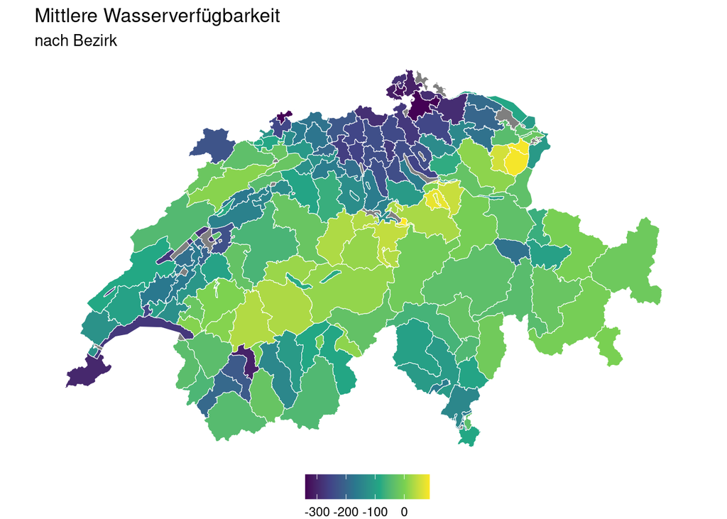

## Aufgabe 1: Herleitung der Formel

In der ersten Übung wollen wir Moran’s $I$ für eine gegebene Choroplethenkarte nachrechnen. Dazu nehmen wir die Formel für Moran’s $I$ und zerlegen sie in Einzelteile, die wir dann Schritt für Schritt für unsere Daten berechnen. So teilen wir ein vermeintlich komplexes Problem in überschaubare Einzelteile. Dieses Vorgehen illustriert ausserdem sehr schön ein generelles (Spatial) Data Science Prinzip. Divide and Conquer - Teile und Herrsche: Teile ein komplexes Probelm in kleinere, beherrschbare Unterprobleme. Wir beginnen mit dem ersten Bruch und berechnen dabei zuerst den Zähler, dann dem Nenner. So können wir den Bruch auflösen und uns danach dem zweiten Bruch zuwenden:

$$I = \frac{n}{\sum_{i=1}^n (y_i - \bar{y})^2} \times \frac{\sum_{i=1}^n \sum_{j=1}^n w_{ij}(y_i - \bar{y})(y_j - \bar{y})}{\sum_{i=1}^n \sum_{j=1}^n w_{ij}}$$

**Bruch 1**

Widmen wir uns dem ersten Bruch:

$$\frac{n}{\sum_{i=1}^n (y_i - \bar{y})^2}$$

*Zähler (von Bruch 1)*

Beginnen wir mit dem Zähler, $n$. Dies ist lediglich die Anzahl Messwerte in unserem Datensatz, also die Anzahl Bezirke.

```r
n <- nrow(wasser_bezirke)
n
```

```
[1] 192
```

*Nenner (von Bruch 1)*

Der Nenner des ersten Bruches (${\sum_{i=1}^n (y_i - \bar{y})^2}$) ist sehr ähnlich der Berechnung der Varianz:

Summiere für alle Messwerte (von $i = 1$ bis $n$) das Quadrat der Differenz zwischen dem jeweiligen Messwert und dem Durchschnitt aller Messwerte.

Also berechnen wir zuerst diese Differenzwerte (Messwert minus Mittelwert):

```r
# Die Werte aller Bezirke:
y <- wasser_bezirke$wasserverfuegbarkeit

# Der Durchschnittswert aller Bezirke
ybar <- mean(y, na.rm = TRUE)

# von jedem Wert den Durchschnittswert abziehen:
dy <- y - ybar
```

Welche dieser Zwischenresultate sind Einzelwerte und welche Vektoren? Nun quadrieren wir die Differenzen:

```r
dy_2 <- dy^2
```

und summieren die Differenzen:

```r
dy_sum <- sum(dy_2, na.rm = TRUE)
```

*Zähler durch Nenner dividieren (Bruch 1)*

Beschliessen wir die Bearbeitung des ersten Bruchs indem wir den Zähler durch den Nennen dividieren: `n` durch `dy_sum`.

```r
vr <- n/dy_sum
```

**Bruch 2**

Wenden wir uns nun also dem Bruches der Formel zu.

$$\frac{\sum_{i=1}^n \sum_{j=1}^n w_{ij}(y_i - \bar{y})(y_j - \bar{y})}{\sum_{i=1}^n \sum_{j=1}^n w_{ij}}$$

Hier berechnen wir die Summe aller Gewichte sowie die gewichteten Covarianzen. Wir betrachten immer Messwertpaare, sprich paarweise Vergleiche zweier Raumeinheiten (hier Bezirke). Deshalb haben die zwei Summenzeichen die beiden unterschiedlichen Laufvariablen ($i$ und $j$). Solche paarweise Vergleiche von Werten mit allen anderen Werten können wir elegant mit Kreuzmatrizen abbilden. In der Kreuzmatrix vergleichen wir jeden Messwert mit allen anderen Messwerten. Dabei gibt es zwei Kreuzmatrizen: ($w_{ij}$ ist die erste Kreuzmatrix, $(y_i - \bar{y})(y_j - \bar{y})$ ist die zweite Kreuzmatrix).

*Zähler (Bruch 2)*

Der erste Term, $w_{ij}$, beschreibt die räumlichen Gewichte aller Bezirke. Sind die Bezirke benachbart, dann gilt ein Gewicht von 1, sind sie nicht benachbart, gilt ein Gewicht von 0. Dies entspricht dem Schalter aus der Vorlesung.

Wie wir “benachbart” definieren ist noch offen.

- Die Bezirke müssen sich berühren (dürfen sich aber nicht überlappen): `st_touches()`
- Die Bezirke müssen innerhalb einer bestimmten Distanz zueinander liegen: `st_is_within_distance()`
- Die Bezirke müssen überlappen: `st_overlaps()`

Egal für welche Variante Ihr Euch entscheidet, setzt `sparse = FALSE` damit eine Kreuzmatrix erstellt wird.

```r
w <- st_touches(wasser_bezirke, sparse = FALSE)

w[1:6, 1:6]
```

```
      [,1]  [,2]  [,3]  [,4]  [,5]  [,6]
[1,] FALSE FALSE  TRUE  TRUE FALSE FALSE
[2,] FALSE FALSE  TRUE  TRUE FALSE FALSE
[3,]  TRUE  TRUE FALSE  TRUE FALSE FALSE
[4,]  TRUE  TRUE  TRUE FALSE FALSE FALSE
[5,] FALSE FALSE FALSE FALSE FALSE FALSE
[6,] FALSE FALSE FALSE FALSE FALSE FALSE
```

(Lasst Euch nicht davon beirren, dass wir nun `TRUE` und `FALSE` statt `1` und `0` haben. In R sind `TRUE` und `1` äquivalent, sowie auch `FALSE` und `0`).

Wir sehen hier, dass der erste Bezirk im Datensatz (Zeile 1), den 3. und 4. Bezirk im Datensatz berührt. Er berührt aber den 2., 5. und 6. Bezirk *nicht*. Ob dies stimmt können wir einfach nachprüfen:

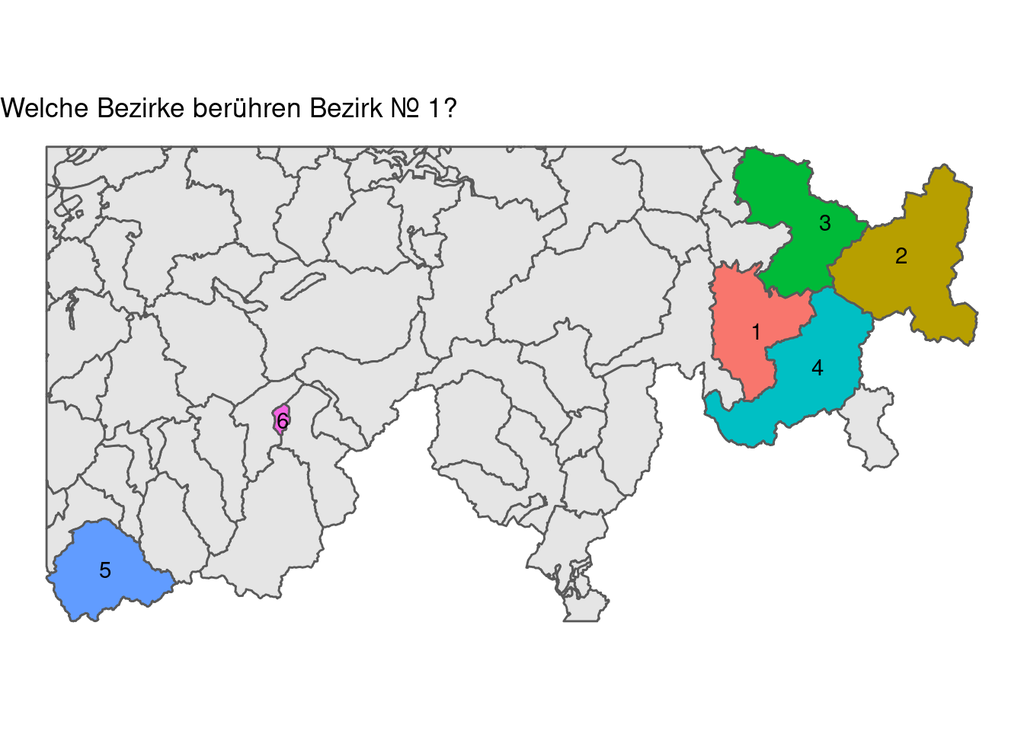

```r
# nur die ersten 6 Geometrien auswählen
wasser_select <- wasser_bezirke %>%
  rowid_to_column() %>% # erstellt eine Spalte rowid mit der Position
  head(6)

# alle anderen Bezirke auf die BoundingBox clippen
# (um als Hintergrundkarte zu dienen)
wasser_selectst_bg <- wasser_select %>%
  st_bbox() %>%
  st_as_sfc() %>%
  st_intersection(wasser_bezirke)

ggplot() +
  geom_sf(data = wasser_selectst_bg) +
  geom_sf(data = wasser_select, aes(fill = factor(rowid))) +
  geom_sf_text(data = wasser_select, aes(label = rowid)) +
  labs(title = "Welche Bezirke berühren Bezirk Nr. 1?") +
  theme_void() +
  theme(legend.position = "none")
```

Um über alle Bezirke zu visualisieren, welche sich berühren, könnt ihr folgende Funktion anwenden:

```r
my_connections <- function(sf_object,relationship_matrix){
  require(sf)
  require(purrr)
  centeroids <- sf::st_centroid(st_geometry(sf_object))

  mycrs <- st_crs(sf_object)

  relationship_transpose <- which(relationship_matrix,arr.ind = TRUE)

  from <- centeroids[relationship_transpose[,1]]
  to <- centeroids[relationship_transpose[,2]]

  connection <- purrr::map2(from,to, ~sf::st_linestring(c(.x,.y))) %>%
    st_sfc() %>%
    st_set_crs(mycrs)
}
```

An erster Stelle kommt euer `sf` Objekt (`wasser_bezirke`) und an zweiter Stelle die eben erstelle Matrix (`w`).

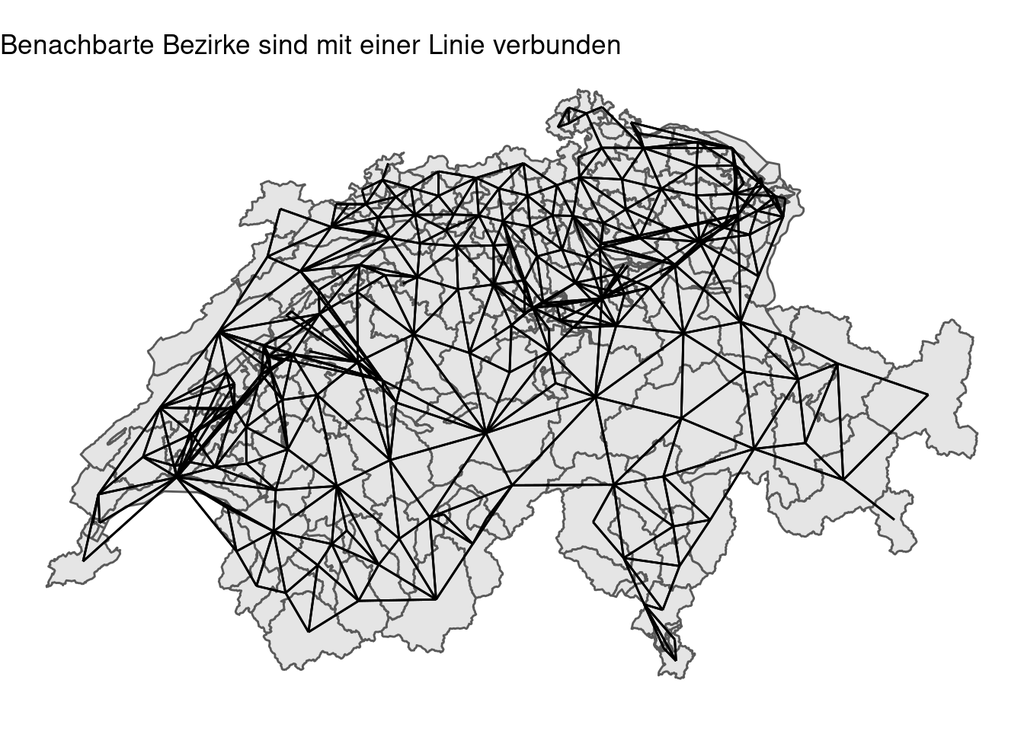

```r
benachbart <- my_connections(wasser_bezirke,w)

ggplot(wasser_bezirke) +
  geom_sf() +
  geom_sf(data = benachbart) +
  theme_void() +
  labs(title = "Benachbarte Bezirke sind mit einer Linie verbunden")
```

Der nächste Teil sollte Euch nun bekannt vorkommen. Die Differenz aller Werte vom Mittelwert aller Werte $(y_i - \bar{y})$ kennen wir schon vom ersten Bruch und haben wir auch bereits gelöst. Nun gilt es paarweise das Produkt der Abweichungen vom Mittelwert (die Covarianz) zu berechnen $(y_i - \bar{y})(y_j - \bar{y})$. DAzu müssen wir *das Produkt aller Wertekombinationen* berechnen. Dies erreichen wir mit der Funktion `tcrossprod()`:

```r
pm <- tcrossprod(dy)
pm[1:6,1:6]
```

```
         [,1]     [,2]      [,3]      [,4]     [,5]      [,6]
[1,] 7156.025 7797.938  8933.269  8662.261 5339.446  8728.465
[2,] 7797.938 8497.434  9734.607  9439.288 5818.408  9511.430
[3,] 8933.269 9734.607 11151.904 10813.589 6665.532 10896.235
[4,] 8662.261 9439.288 10813.589 10485.538 6463.320 10565.676
[5,] 5339.446 5818.408  6665.532  6463.320 3984.011  6512.717
[6,] 8728.465 9511.430 10896.235 10565.676 6512.717 10646.427
```

Nun multiplizieren wir die Covarianzen mit den Gewichten $w$ (Schalter), damit wir nur noch die Werte von den Bezirken haben, die auch effektiv benachbart sind (und eliminieren nicht-benachbarte Werte). Beachtet dass wir hier nun eine Matrix mit einer Matrix multiplizieren.

```r
pmw <- pm * w
w[1:6,1:6]
```

```
      [,1]  [,2]  [,3]  [,4]  [,5]  [,6]
[1,] FALSE FALSE  TRUE  TRUE FALSE FALSE
[2,] FALSE FALSE  TRUE  TRUE FALSE FALSE
[3,]  TRUE  TRUE FALSE  TRUE FALSE FALSE
[4,]  TRUE  TRUE  TRUE FALSE FALSE FALSE
[5,] FALSE FALSE FALSE FALSE FALSE FALSE
[6,] FALSE FALSE FALSE FALSE FALSE FALSE
```

```r
pmw[1:6,1:6]
```

```
         [,1]     [,2]      [,3]      [,4] [,5] [,6]
[1,]    0.000    0.000  8933.269  8662.261    0    0
[2,]    0.000    0.000  9734.607  9439.288    0    0
[3,] 8933.269 9734.607     0.000 10813.589    0    0
[4,] 8662.261 9439.288 10813.589     0.000    0    0
[5,]    0.000    0.000     0.000     0.000    0    0
[6,]    0.000    0.000     0.000     0.000    0    0
```

```r
spmw <- sum(pmw, na.rm = TRUE)
spmw
```

```
[1] 5178725
```

*Nenner (Bruch 2)*

Für den Nenner des zweiten Teils der Formal (des zweiten Bruchs) müssen wir nun nur noch alle Gewichte summieren. Diese Summer entspricht der Anzahl effektiv benachbarter Bezirke und kann Anzahl der $TRUE$-Werte in $w$ bestimmt werden.

```r
smw <- sum(w, na.rm = TRUE)
```

**Auflösung (Bruch 2)**

So können wir den zweiten Bruch auflösen und berechnen:

```r
sw  <- spmw / smw
```

**Brüche Multiplizieren**

Der allerletzte Schritt besteht darin, die Werte aus den beiden Brüchen miteinander zu multiplizieren.

```r
MI <- vr * sw
MI
```

```
[1] 0.5454743
```

## Aufgabe 2: Morans I fuer Kantone berechnen

Nun wollen wir die Wasserverfügbarkeitswerte auf der Ebene der Kantone aggregieren und untersuchen, ob und wie sich Morans $I$ verändert. Importiere dafür den Datensatz “kantone.gpkg” aus RaumAn1 (s.u.), allenfalls musst du das CRS noch setzen. Aggregiere Wasserqualitätswerte auf Ebene der Kantone, visualisiere diese anschliessend und berechne danach wieder Moran’s $I$ wie eben demonstriert.

- kantone.gpkg

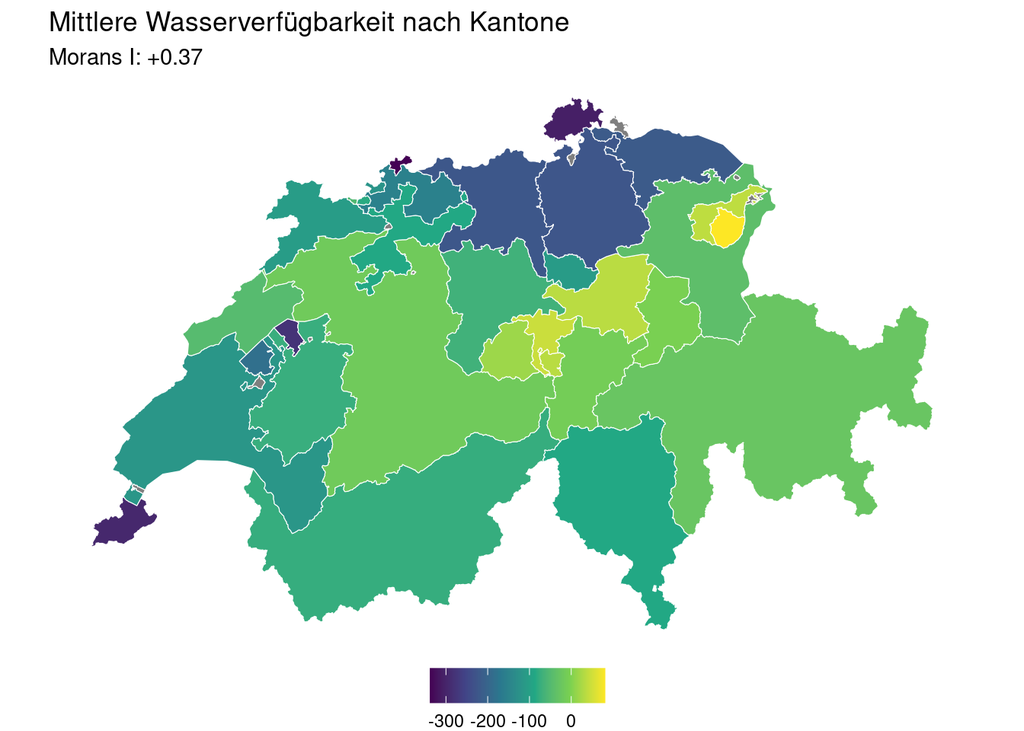